# Optimization

**Author:** Paul Schrimpf  
**Date:** 2019-10-17

This work is licensed under a [Creative Commons Attribution-ShareAlike 4.0 International License](http://creativecommons.org/licenses/by-sa/4.0/).

### About this document

This document was created using Weave.jl. The code is available in [the course github repository](https://bitbucket.org/paulschrimpf/econ526). The same document generates both static webpages and associated jupyter notebooks. This is meant to accompany [the lecture notes for 526](http://faculty.arts.ubc.ca/pschrimpf/526/526.html).

$$\def\indep{\perp\!\!\!\perp}
\def\Er{\mathrm{E}}
\def\R{\mathbb{R}}
\def\En{{\mathbb{E}_n}}
\def\Pr{\mathrm{P}}
\newcommand{\norm}[1]{\left\Vert {#1} \right\Vert}
\newcommand{\abs}[1]{\left\vert {#1} \right\vert}
\DeclareMathOperator*{\argmax}{arg\,max}
\DeclareMathOperator*{\argmin}{arg\,min}
\def\inprob{\,{\buildrel p \over \rightarrow}\,}
\def\indist{\,{\buildrel d \over \rightarrow}\,}$$

# Optimization Algorithms

The goal of this notebook is to give you some familiarity with numeric optimization.

Numeric optimization is important because many (most) models cannot be fully solved analytically. Numeric results can be used to complement analytic ones. Numeric optimization plays a huge role in econometrics.

In these notes, we will focus on minimization problems following the convention in mathematics, engineering, and most numerical libraries. It is easy to convert between minimization and maximization, and we hope that this does not lead to any confusion.

# Heuristic searches

The simplest type of optimization algorithm are heuristic searches. Consider the problem:

$$\min_x f(x)$$

with $f:\R^n \to \R$. Heuristic search algorithms consist of

1. Evaluate $f$ at a collection of points
2. Generate a new candidate point, $x^{new}$. Replace a point in the current collection with $x^{new}$ if $f(x^{new})$ is small enough.
3. Stop when function value stops decreasing and/or collection of points become too close together.

There are many variants of such algorithms with different ways of generating new points, deciding whether to accept the new point, and deciding when to stop. Here is a simple implementation and animation of the above idea. In the code below, new points are drawn randomly from a normal distribution, and new points are accepted whenever $f(x^{new})$ is smaller than the worst existing function value.

```julia
using Distributions, Plots
ENV["GKSwstype"]="nul" # for running Plots with GR backend without DISPLAY (e.g. over ssh)
```

“nul”

```julia
"""
     banana(a,b)

  Returns the Rosenbrock function with parameters a, b.
"""
function banana(a,b)
  x->(a-x[1])^2+b*(x[2]-x[1]^2)^2
end
f = banana(1.0,1.0)

x0 = [-2.0, 3.0]
```

2-element Array{Float64,1}: -2.0 3.0

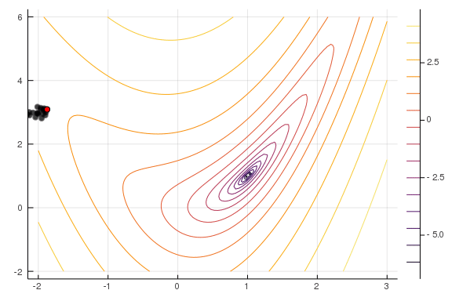

random search

```julia
result = minrandomsearch(f, x0, 20, var0=0.1, vshrink=0.5, vtol=1e-3 )
gif(result[5], "randsearch.gif", fps=5);
```

There are many other heuristic search algorithms. A popular deterministic one is the Nelder-Mead simplex. Popular heuristic search algorithms that include some randomness include simulated annealing and particle swarm. Each of the three algorithms just mentioned are available in [Optim.jl](https://julianlsolvers.github.io/Optim.jl/stable/#algo/nelder_mead/). These heuristic searches have the advantage that they only function values (as opposed to also requiring gradients or hessians, see below). Some heuristic algorithms, like simulated annealing, can be shown to converge to a global (instead of local) minimum under appropriate assumptions. Compared to algorithms that use more information, heuristic algorithms tend to require many more function evaluations.

# Gradient descent

Gradient descent is an iterative algorithm to find a local minimum. As the name suggests, it consists of descending toward a minimum in the direction opposite the gradient. Each step, you start at some $x$ and compute $x_{new}$

1. Given current $x$, compute $x_{new} = x - \gamma Df_{x}$
2. Adjust $\gamma$ depending on whether $f(x_{new})<f(x)$
3. Repeat until $\norm{Df_{x}}$, $\norm{x-x_{new}}$, and/or $\abs{f(x)-f(x_{new})}$ small.

```julia
using ForwardDiff, LinearAlgebra
```

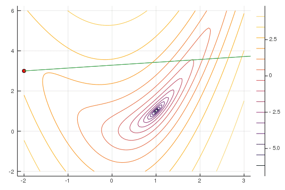

gradient descent

```julia
result = graddescent(f, x0)
gif(result[5], "graddescent.gif", fps=5);
```

Although an appealing and intuitive idea, the above example illustrates that gradient descent can perform surprisingly poorly in some cases. Nonetheless, gradient descent is useful for some problems. Notably, (stochastic) gradient descent is used to fit neural networks, where the dimension of `x` is so large that computing the inverse hessian in (quasi) Newton’s method is prohibitively time consuming.

# Newton’s method

Newton’s method and its variations are often the most efficient minimization algorithms. Newton’s method updates $x$ by minimizing a second order approximation to $f$. Specifically:

1. Given $x$ set $x_{new} = x - (D^2f_x)^{-1} Df_x$
2. Repeat until $\norm{Df_{x}}$, $\norm{x-x_{new}}$, and/or $\abs{f(x)-f(x_{new})}$ small.

```julia
result = newton(f, x0)
```

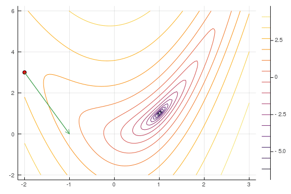

newton

```julia
gif(result[5], "newton.gif", fps=5);
```

Newton’s method tends to take relatively few iterations to converge for well-behaved functions. It does have the disadvantage that hessian and its inverse can be time consuming to compute, especially when the dimension of $x$ is large. Newton’s method can be unstable for functions that are not well approximated by their second expansion. This problem can be mitigated by combining Newton’s method with a line search or trust region.

## Line search

Line searches consist of approximately minimizing $f$ along a given direction instead of updating $x$ with a fixed step size. For Newton’s method, instead of setting $x_{new} = x - (D^2f_x)^{-1} Df_x$, set $x_{new} \approx \argmin_{\delta} f(x - \delta (D^2f_x)^{-1} Df_x)$ where $\delta$ is a scalar. This one dimensional problem can be solved fairly quickly. Line search can also be combined with gradient descent.

## Trust region

Instead of setting
$$x_{new} = x - (D^2f_x)^{-1} Df_x =
\argmin_{\tilde{x}} f(x) + Df_x (\tilde{x} - x) + \frac{1}{2}
(\tilde{x}-x)^T Df_x (\tilde{x} - x)$$
to the unconstrained minimizer of a local second order approximation, trust region methods introduce an region near $x$ where the approximation is trusted, and set
$$x_{new} = \argmin_{\tilde{x} \in TR(x)} f(x) + Df_x (\tilde{x} - x) + \frac{1}{2}
(\tilde{x}-x)^T D^2 f_x (\tilde{x} - x).$$
Often $TR(x) = \{\tilde{x} : \norm{x - \tilde{x}} < r\}$. The radius of the trust region is then increased or decreased depending on $f(x_{new})$.

## Quasi-Newton

Quasi-Newton methods (in particular the BFGS algorithm) are probably the most commonly used nonlinear optimization algorithm. Quasi-Newton methods are similar to Newton’s method, except instead of evaluating the hessian directly, quasi-Newton methods build an approximation to the hessian from repeated evaluations of $Df_x$ at different $x$.

Optim.jl contains all the algorithms mentioned above. [Their advice on choice of algorithm is worth following.](https://julianlsolvers.github.io/Optim.jl/stable/#user/algochoice/).

## Details matter in practice

In each of the algorithms above, we were somewhat cavalier with details like how to adjust step sizes and trust regions and what it means to approximately minimize during a line search. In practice these details can be quite important for how long an algorithm takes and whether it succeeds or fails. Different implementations of algorithms have different details. Often the details can be adjusted through some options. It can be worthwhile to try multiple implementations and options to get the best performance.

# Constrained optimization

Constrained optimization is a bit harder than unconstrained, but uses similar ideas. For simple bound constraints, like $x\geq 0$ it is often easiest to simply transform to an unconstrained case by optimizing over $y = \log(x)$ instead.

For problems with equality constraints, one can apply Newton’s method to the first order conditions.

The difficult case is when there are inequality constraints. Just like when solving analytically, the difficulty is figuring out which constraints bind and which do not. For inequality constraints, we will consider problems written in the form:
$$\min_{x \in \R^n} f(x) \text{ s.t. } c(x) \geq 0$$

## Interior Point Methods

Interior point methods circumvent the problem of figuring out which constraints bind by approaching the optimum from the interior of the feasible set. To do this, the interior point method applies Newton’s method to a modified version of the first order condition. The unmodified first order conditions can be written
$$\begin{align*}
0 = & Df_x - \lambda^T Dc_x \\
0 = & \lambda_i c_i(x) \\
\lambda \geq & 0 \\
c(x) \geq & 0
\end{align*}$$
A difficulty with these conditions is that solving them can require guessing and checking which combinations of constraints bind and which do not. Interior point methods get around this problem by beginning with an interior $x$ and $\lambda$ such that $\lambda>0$ and $c(x)>0$. They are then updated by applying Newton’s method to the equations
$$\begin{align*}
0 = & Df_x - \lambda^T Dc_x \\
\mu = & \lambda_i c_i(x) \\
\end{align*}$$
where there is now a $\mu$ in place of $0$ in the second equation. $x$ and $\lambda$ are updated according to Newton’s method for this system of equations. In particular, $x_{new} = x + \Delta_x$ and $\lambda_{new}= \lambda + \Delta_\lambda$, where
$$\begin{align*}
\begin{pmatrix} - ( Df_x - \lambda^T Dc_x) \\
\mu 1_m - diag(c(x)) \lambda
\end{pmatrix} = \begin{pmatrix}
D^2 f_x - D^2 (\lambda c)_x & -Dc_x^T \\
\lambda Dc_x & diag(c(x))
\end{pmatrix} \begin{pmatrix}
\Delta_x \\
\Delta_\lambda
\end{pmatrix}
\end{align*}$$
Over iterations $\mu$ is gradually decreased toward $0$. Here is one simple implementation.

```julia
f = banana(1.0,1.0)
x0 = [3.0, 0.0]
function constraint(x)
  [x[1] + x[2] - 2.5]
end
```

constraint (generic function with 1 method)

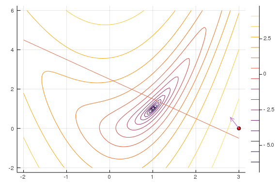

interior point

```julia
result = interiorpoint(f, x0, constraint; maxiter=100)
gif(result[5], "ip.gif", fps=5);
```

Optim.jl includes an interior point method. IPOPT is another popular implementation. As above, the details of the algorithm can be important in practice. It can be worthwhile to experiment with different methods for updating $\mu$, using a more sophisticated line search or trust region, and perhaps replacing the computation of the hessian with a quasi-Newton approximation.

It has been proven that interior point methods converge relatively quickly for convex optimization problems.

## Sequential quadratic programming

Sequential quadratic programming relies on the fact that there are efficient methods to compute the solution to quadratic programs — optimization problems with quadratic objective functions and linear constraints. We can then solve a more general optimization problem by solving a sequence of quadratic programs that approximate the original problem.

Sequential quadratic programming is like a constrained version of Newton’s method. Given a current $x$ and $\lambda$ the new $x$ solves
$$\begin{align*}
x_{new} \in \argmin_{\tilde{x}} & f(x) + Df_x (\tilde{x} - x) +
\frac{1}{2} (\tilde{x}-x)^T (D^2 f_x + D^2 (\lambda^T c)_x) (\tilde{x} - x) \\
\text{ s. t. } & c(x) + Dc_{x} (\tilde{x} - x) \geq 0
\end{align*}$$
and the new $\lambda$ is set to the value of the multipliers for this problem.

This quadratic program (an optimization problem with a quadratic objective function and linear constraints) can be solved fairly efficiently if $(D^2 f_x + D^2 (\lambda^T c)_x)$ is positive semi-definite.[^1]

One could also incorporate a trust region or line search into the above algorithm. Here is one simple implementation.

```julia
using Convex, ECOS
```

```julia
x0 = [0.0, 0.0]
result = sequentialquadratic(f, x0, constraint; maxiter=100)
```

Iter 0: f=1.0, λ=[5.744129812962317e7], c(x)=[-2.5], TR=0.6666666666666666, norm(foc)=1.4142135623730951 Iter 1: f=1.0, λ=[8.82630652026277e7], c(x)=[-2.5], TR=0.4444444444444444, norm(foc)=1.4142135623730951 Iter 2: f=5.038440570604318, λ=[1.1753817640813076e8], c(x)=[-0.07212807174 958691], TR=0.6666666666666666, norm(foc)=1.6644012806823975e8 Iter 3: f=1.6448771839550929, λ=[2.416203521589231e-9], c(x)=[0.48372602542 892373], TR=1.0, norm(foc)=8.727700659672426 Iter 4: f=0.5840086806647102, λ=[4.4551946746239154e-10], c(x)=[0.675758196 7033381], TR=1.0, norm(foc)=4.6137298556725534 Iter 5: f=0.23916925350447604, λ=[7.569576370538181e-11], c(x)=[0.499383048 6552775], TR=1.0, norm(foc)=2.5160755086622277 Iter 6: f=0.09743531200157135, λ=[9.38238253913904e-10], c(x)=[0.1987192291 2166484], TR=1.0, norm(foc)=1.40581442153938 Iter 7: f=0.040343557701675914, λ=[0.02685022552990332], c(x)=[4.2504577635 327223e-10], TR=1.0, norm(foc)=0.7553410661599463 Iter 8: f=0.027527315271240967, λ=[0.08320080939959254], c(x)=[1.3213163896 352853e-10], TR=1.0, norm(foc)=0.3652756468851557 Iter 9: f=0.024131472985838866, λ=[0.08679517745067436], c(x)=[8.8190521552 17832e-10], TR=1.0, norm(foc)=0.1831946208733258 Iter 10: f=0.023256002358673446, λ=[0.08778281083823443], c(x)=[2.176565594 4250284e-10], TR=1.0, norm(foc)=0.09173401109091146 Iter 11: f=0.023033667836213356, λ=[0.08804971131022993], c(x)=[2.176051783 209232e-9], TR=1.0, norm(foc)=0.04591272206539734 Iter 12: f=0.02297758351219684, λ=[0.08811530260655176], c(x)=[2.1821664475 396574e-9], TR=1.0, norm(foc)=0.022967012802199437 Iter 13: f=0.022963508642272278, λ=[0.08812480456673913], c(x)=[3.764233369 452086e-10], TR=1.0, norm(foc)=0.011500723092885471 Iter 14: f=0.0229599744412804, λ=[0.08812974655873822], c(x)=[1.36619604518 27326e-10], TR=1.0, norm(foc)=0.005756385618588163 Iter 15: f=0.022959088150398085, λ=[0.0881314107961055], c(x)=[4.5647441382 3571e-10], TR=1.0, norm(foc)=0.002880464885383854 Iter 16: f=0.02295886732972351, λ=[0.0881263017672415], c(x)=[1.07529629644 88688e-9], TR=1.0, norm(foc)=0.001456169724223254 Iter 17: f=0.022958810562596636, λ=[0.08812727182962203], c(x)=[3.745093124 507548e-10], TR=1.0, norm(foc)=0.0007266128616736104 Iter 18: f=0.022958797295923792, λ=[0.08812916326165048], c(x)=[9.805600775 791845e-10], TR=1.0, norm(foc)=0.0003909086741240457 Iter 19: f=0.022958793324829984, λ=[0.08812981693441531], c(x)=[1.730438015 101754e-10], TR=1.0, norm(foc)=0.00020768034064370404 Iter 20: f=0.022958792149509473, λ=[0.08812993623802398], c(x)=[1.063815702 195825e-10], TR=1.0, norm(foc)=0.00010132460936763705 Iter 21: f=0.02295879187493447, λ=[0.08813033423408839], c(x)=[1.4879342202 789303e-10], TR=1.0, norm(foc)=4.905856373221587e-5

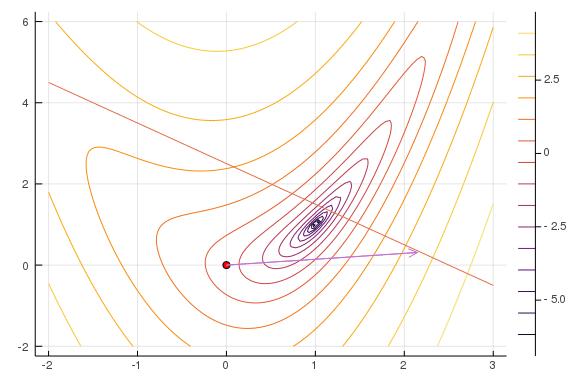

sqp

```julia
gif(result[5], "sqp.gif", fps=5);
```

### SLQP active Set

SLQP active set methods use a linear approximation to the optimization problem to decide which constraints are “active” (binding). In each iteration, a linear approximation to the original problem is first solved. The constraints that bind in linear approximation are then assumed to bind in the full problem, and we take a Newton step accordingly.

## Augmented Lagrangian

Augmented Lagragian methods convert a constrained minimization problem to an unconstrained problem by adding a penalty that increases with the constraint violation to the Lagrangian.

## Barrier methods

Barrier methods refer to adding a penalty that increases toward $\infty$ as the constraints get close to violated (such as $\log(c(x))$). Barrier methods are closely related to interior point methods. Applying Newton’s method to a log-barrier penalized problem gives rise to something very similar to our `interiorpoint` algorithm above.

# Strategies for global optimization

The above algorithms will all converge to local minima. Finding a global minimum is generally very hard. There are a few algorithms that have been proven to converge to a global optimum, such a DIRECT-L in `NLopt`. However, these algorithms are prohibitively time-consuming for even moderate size problems.

Randomization is a good strategy for avoiding local minima. Some algorithms with randomization, like simulated annealing, can be shown to converge to the global optimum with high probability. In practice, these are also often too inefficient for moderate size problems.

A good practical approach is to use an algorithm that combines randomization with some model-based search. A common approach is to use a variant of Newton’s method starting from a bunch of randomly chosen initial values.

Algorithms that combine a linear or quadratic approximation to the objective function with some randomness in the search direction can also be useful. An example is stochastic gradient descent, which is often used to fit neural networks. I have had good experience with [CMA-ES](http://cma.gforge.inria.fr/). It worked well to estimate the finite mixture model in Einav, Finkelstein, and Schrimpf (2015).

Bayesian methods can also be used for optimization and will naturally include some randomization in their search. Hamiltonian Monte-Carlo methods, which incorporate gradient information in their search, are likely to be efficient. See [`DynamicHMC.jl`](https://github.com/tpapp/DynamicHMC.jl).

Einav, Liran, Amy Finkelstein, and Paul Schrimpf. 2015. “ The Response of Drug Expenditure to Nonlinear Contract Design: Evidence from Medicare Part D *.” *The Quarterly Journal of Economics* 130 (2): 841–99. https://doi.org/10.1093/qje/qjv005.

[^1]: Most for Convex program solvers are designed to accept semidefinite programs instead of quadratic programs. A [quadratic program can be re-written as a semidefinite program](https://math.stackexchange.com/q/2256243). A solver such as SCS, ECOS, or Mosek can then be used. Fortunately, Convex.jl will automatically take care of any necessary transformation.

Published from optimization.jmd using Weave.jl on 2019-10-17.